# 10 Model explanation

#### Predictive Modeling and Analytics

Marko Robnik-Sikonja, November 2018

## Explain models and their predictions

We use package ExplainPrediction which generates explanations for methods EXPLAIN and IME. Let us first prepare training and testing data. We use random split of iris data set (70% for training, 30% for testing).

```r
trainIdxs <- sample(x=nrow(iris), size=0.7*nrow(iris), replace=FALSE)
testIdxs <- (1:nrow(iris))[-trainIdxs]
```

We build random forests classification model using CORElearn package with certain parameters

```r
require(CORElearn)
modelRF <- CoreModel(Species ~ ., iris[trainIdxs,], model="rf", minNodeWeightRF=5, rfNoTrees=100)
print(modelRF) # simple visualization, test also others available visualizations, see help for function plot.CoreModel
```

```
$`modelID`
[1] 0

$class.lev
[1] "setosa"     "versicolor" "virginica"

$model
[1] "rf"

$formula
Species ~ Sepal.Length + Sepal.Width + Petal.Length + Petal.Width
<environment: 0x0000000025f563b0>

$noClasses
[1] 3

$priorClassProb

    setosa versicolor  virginica
 0.3619048  0.3047619  0.3333333

$avgTrainPrediction
[1] 0

$noNumeric
[1] 4

$noDiscrete
[1] 1

$discAttrNames
[1] "Species"

$discValNames
$discValNames[[1]]
[1] "setosa"     "versicolor" "virginica"


$numAttrNames
[1] "Sepal.Length" "Sepal.Width"  "Petal.Length" "Petal.Width"

$discmap
[1] 1

$nummap
[1] 2 3 4 5

$skipmap
integer(0)

attr(,"class")
[1] "CoreModel"
```

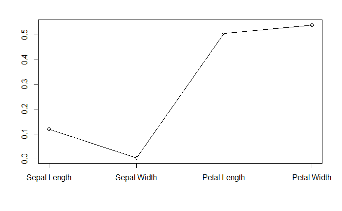

```r
plot(modelRF) # importance of the variables
```

We test the predictive performance of the created model on test set. We use statistics computed by `modelEval` function.

```r
pred <- predict(modelRF, iris[testIdxs,], type="both") # prediction on testing set
mEval <- modelEval(modelRF, iris[["Species"]][testIdxs], pred$class, pred$prob)
print(mEval) # evaluation of the model
```

```
$`accuracy`
[1] 0.9333333

$averageCost
[1] 0.06666667

$informationScore
[1] 1.43483

$AUC
[1] 0.9962963

$predictionMatrix
           setosa versicolor virginica
setosa         12          0         0
versicolor      0         16         2
virginica       0          1        14

$sensitivity
[1] 0

$specificity
[1] 0

$brierScore
[1] 0.07883398

$kappa
[1] 0.8988764

$precision
[1] 0

$recall
[1] 0

$Fmeasure
[1] 0

$Gmean
[1] 0

$KS
[1] 0

$TPR
[1] 0

$FPR
[1] 0
```

The model is quite accurate. We generate the model explanation and its visualization.

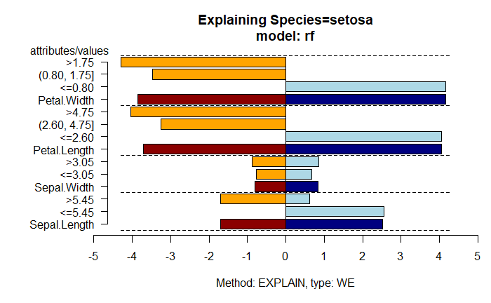

```r
require(ExplainPrediction)
explainVis(modelRF, iris[trainIdxs,], iris[testIdxs,], method="EXPLAIN",visLevel="model")
```

Similarly we can generate explanations for classification of individual instances, we chose the first from the test set and visualize it.

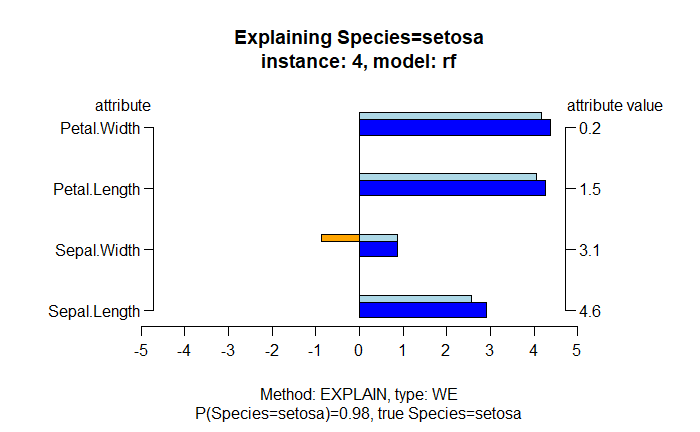

```r
explainVis(modelRF, iris[trainIdxs,], iris[testIdxs[1],], method="EXPLAIN",visLevel="instance")
```

We can do similar visualizations for regression models. As an example we take a regression tree and the artificial data generator (Gaussians) contained in `CORElearn` package.

```r
trainReg <- regDataGen(100)
testReg <- regDataGen(20)
modelRT <- CoreModel(response~., trainReg, model="regTree", modelTypeReg=1)
modelRT
```

```
$`modelID`
[1] 1

$class.lev
NULL

$model
[1] "regTree"

$formula
response ~ a1 + a2 + a3 + a4 + x1 + x2 + x3 + x4 + x5 + x6
<environment: 0x0000000022b8f8b8>

$noClasses
[1] 0

$priorClassProb
[1] 0

$avgTrainPrediction
[1] 0.4266612

$noNumeric
[1] 7

$noDiscrete
[1] 4

$discAttrNames
[1] "a1" "a2" "a3" "a4"

$discValNames
$discValNames[[1]]
[1] "0" "1"

$discValNames[[2]]
[1] "a" "b" "c" "d"

$discValNames[[3]]
[1] "0" "1"

$discValNames[[4]]
[1] "a" "b" "c" "d"


$numAttrNames
[1] "response" "x1"       "x2"       "x3"       "x4"       "x5"       "x6"

$discmap
[1] 2 3 4 5

$nummap
[1]  1  6  7  8  9 10 11

$skipmap
integer(0)

attr(,"class")
[1] "CoreModel"
```

We test the predictive performance on the test set. We use statistics computed by `modelEval` function.

```r
pred <- predict(modelRT, testReg) # prediction on testing set
mEval <- modelEval(modelRT, testReg[["response"]], pred)
print(mEval) # evaluation of the model
```

```
$`MSE`
[1] 0.8316981

$RMSE
[1] 0.8235135

$MAE
[1] 0.6239331

$RMAE
[1] 0.8621335
```

Generate model explanation using defaults.

[figure not shown]

```r
explainVis(modelRT, trainReg, trainReg, visLevel="model")
```

Generate explanation for the fifth instance in test set using defaults.

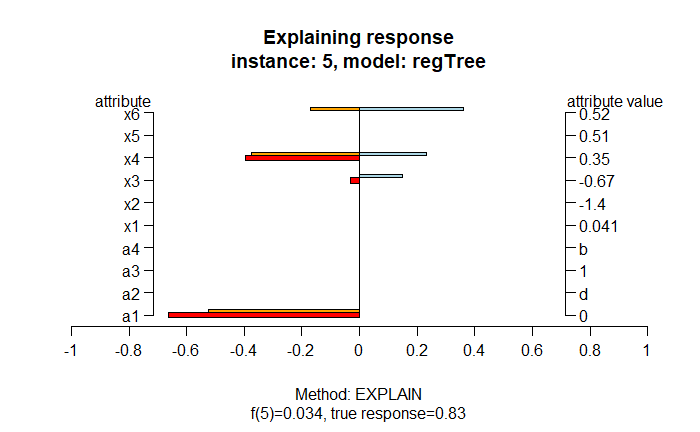

```r
explainVis(modelRT, trainReg, testReg[5,], visLevel="instance")
```

### Exercise

Use random forest model from CORElearn package on a classification data set predicting diabetes in Pima indian female population and explain the obtained model with `explainVis` function.